# Lecture 1: Regression, identification, and the OLS estimator

Economics 527: Econometric Methods

Vadim Marmer, UBC

# Motivation and data

## A motivating example: Return to education

- Suppose wages are generated according to:
  $$\begin{aligned}
  \ln \text{Wage} = \beta_1 &+ {\color{blue}\beta_2}\,\text{Education} + \beta_3\,\text{Gender} + \beta_4\,\text{Race} \\
  &+ \beta_5\,\text{Urban} + \beta_6\,\text{Experience} + U.
  \end{aligned}$$
- We have a sample of workers and, for each worker, we observe Wage, Education, etc.
- $U$ collects everything besides Education, Gender, etc. that affects wages. Ability is first on that list, and it is unobserved (latent).
- The unknown coefficient ${\color{blue}\beta_2}$ measures the return to education, holding everything else fixed.
- Questions/Issues:
  - Why in this equation $\beta_2$ measures the return to education;
  - How to “learn” $\beta_2$ from random data;
  - What data randomness means;
  - What has to be assumed about the unobserved $U$ to be able to learn $\beta_2$.

## Levels and logs

- **Level-level**, $y = \beta x$:
  $$\beta = \frac{dy}{dx},$$
  and the proportional change in $y$ per unit of $x$ is $\beta / y$, which depends on where $y$ is.
- **Log-level**, $\ln y = \beta x$:
  $$\beta = \frac{d \ln y}{d x} = \frac{dy/dx}{y},$$
  so $\beta$ is the proportional rate of change of $y$ with respect to $x$. Multiply by 100 for a percentage.
- **Log-log**, $\ln y = \beta \ln x$:
  $$\beta = \frac{d \ln y}{d \ln x} = \frac{dy/y}{dx/x},$$
  the elasticity of $y$ with respect to $x$.

## Logs often “work better”

- Wages are bounded below by zero and have a long right tail. Their log is close to symmetric.

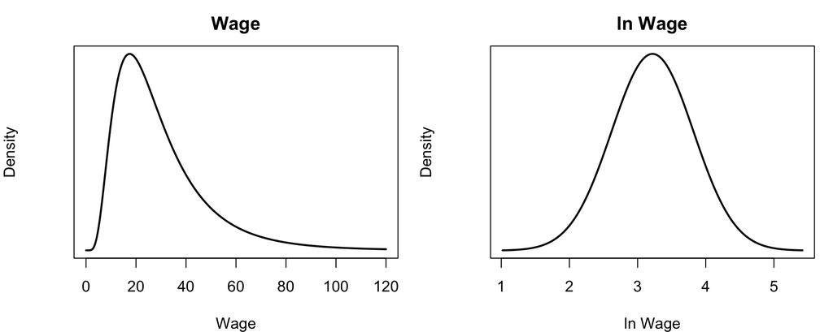

- A symmetric dependent variable is not required by anything that follows, but specifications with logs often “work better” in practice.

## Data

- We observe a **sample** of $n$ workers:
  $$\{(Y_i, X_i) : i = 1, \ldots, n\}.$$
- For worker $i$, $Y_i = \ln \text{Wage}_i$ is a scalar ($1\times 1$) and $X_i$ stacks the $k$ regressors, with a $1$ in the first position for the intercept:
  $$X_i = \begin{pmatrix} 1 \\ \text{Educ}_i \\ \text{Gender}_i \\ \vdots \end{pmatrix} \quad (k \times 1),
  \qquad
  \beta = \begin{pmatrix} \beta_1 \\ \beta_2 \\ \vdots \\ \beta_k \end{pmatrix} \quad (k \times 1).$$
- The wage equation for worker $i$ is
  $$Y_i = X_i^\top \beta + U_i = \sum_{j=1}^{k} X_{ij}\,\beta_j + U_i,$$
  where $X_i^\top \beta = \beta^\top X_i$ is a scalar.

## What is random and what is fixed

- $\beta$ is **fixed** and unknown.
- $X_i$, $U_i$, and therefore $Y_i$ are **random**.
- The **population** is the distribution that generates $\{(Y_i, X_i) : i = 1, \ldots, n\}$, a probability distribution rather than a group of people.
- In a cross-section, each observation is a different worker, so we take the observations to be drawn **independently and identically distributed**:
  $$(Y_i, X_i) \text{ are iid, with joint distribution } F_{Y, X_1, \ldots, X_k}.$$
- Note that independence is between $(Y_i,X_i)$ and $(Y_j,X_j)$ for $i \neq j$, not between $Y_i$ and $X_i$.
- Under the iid assumption, we can take the population to be the joint distribution of one observation $(Y_i, X_i)$.

## Modelling the randomness

- A random experiment has a sample space $\Omega$ of outcomes $\omega$. These are possible states of the world.
- Let $X$ denote education and $V$ ability.
- The pair $(X, V)$ is a function from $\Omega$ to $\mathbb{R}^2$: for the state of the world $\omega$, $X(\omega)$ is the education and $V(\omega)$ is the ability.

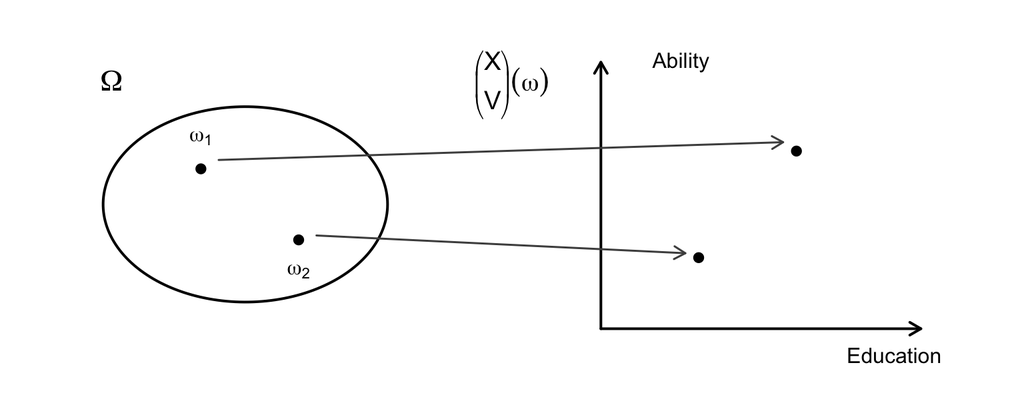

- A probability $\mathrm{P}$ assigns to each event $A$ a number $\mathrm{P}(A) \in [0,1]$. It induces a distribution for $(X, V)$.
- The joint CDF of $(X,V)$ is a statement about sets of outcomes: for all $x, v \in \mathbb{R}$,
  $$\begin{aligned}
  F_{X,V}(x,v) &= \mathrm{P}(X \le x,\, V \le v) \\
  &= \mathrm{P}\big(\{\omega \in \Omega : X(\omega) \le x,\ V(\omega) \le v\}\big).
  \end{aligned}$$

# Probability

## Random variables and the CDF

- A random variable is a map $Y : \Omega \to \mathbb{R}$. For a set $A \subset \mathbb{R}$,
  $$\mathrm{P}(Y \in A) = \mathrm{P}\big(\{\omega : Y(\omega) \in A\}\big).$$
- Taking $A = (-\infty, y]$ gives the **cumulative distribution function**:
  $$F_Y(y) = \mathrm{P}(Y \le y), \qquad y \in \mathbb{R}.$$
- Properties:
  - $F_Y$ is nondecreasing and right-continuous, $F_Y(y) \to 0$ as $y \to -\infty$ and $F_Y(y) \to 1$ as $y \to \infty$;
  - $\mathrm{P}(a < Y \le b) = F_Y(b) - F_Y(a)$;
  - a jump of $F_Y$ at $y_1$ has size $\mathrm{P}(Y = y_1)$; where $F_Y$ is continuous, $\mathrm{P}(Y = y_1) = 0$.

## Continuous random variables and the PDF

- When $F_Y$ is differentiable, the **probability density function** is
  $$f_Y(y) = \frac{d F_Y(y)}{dy}, \qquad\text{so}\qquad F_Y(y) = \int_{-\infty}^{y} f_Y(v)\, dv.$$
- $f_Y(y) \ge 0$, $\displaystyle\int_{-\infty}^{\infty} f_Y(y)\, dy = 1$, and for $A \subset \mathbb{R}$,
  $$\mathrm{P}(Y \in A) = \int_A f_Y(y)\, dy.$$
- A density is not a probability: $\mathrm{P}(Y = y) = 0$ for every $y$, and $f_Y(y)$ can exceed one.
- Everything in this course is written for the continuous case. The discrete case replaces integrals with sums.

## Expectation

- For a function $h$,
  $$\mathrm{E}\left[h(Y)\right] = \int_{-\infty}^{\infty} h(y)\, f_Y(y)\, dy.$$
- Throughout, every expectation we write down is assumed to exist and to be finite.
- $\mathrm{E}\left[Y\right]$ is the first moment, $\mathrm{E}\left[Y^2\right]$ the second, and
  $$\mathrm{Var}\left(Y\right) = \mathrm{E}\left[(Y - \mathrm{E}\left[Y\right])^2\right] = \mathrm{E}\left[Y^2\right] - (\mathrm{E}\left[Y\right])^2.$$
- The mean is the best constant predictor of $Y$ under squared loss:
  $$\mathrm{E}\left[(Y - c)^2\right] = \mathrm{E}\left[(Y - \mathrm{E}\left[Y\right])^2\right] + (\mathrm{E}\left[Y\right] - c)^2 \ge \mathrm{Var}\left(Y\right),$$
  with equality only at $c = \mathrm{E}\left[Y\right]$. (The cross term $2(\mathrm{E}\left[Y\right] - c)\,\mathrm{E}\left[Y - \mathrm{E}\left[Y\right]\right]$ is zero.)
- Under absolute loss the minimiser of $\mathrm{E}\left[|Y - c|\right]$ is the median instead. Which loss we use decides which feature of the distribution we end up estimating.

## Joint distributions

- For two random variables $Y$ and $X$ on the same $\Omega$:
  $$\begin{aligned}
  F_{Y,X}(y, x) &= \mathrm{P}(Y \le y,\, X \le x),\\
  f_{Y,X}(y, x) &= \frac{\partial^2 F_{Y,X}(y,x)}{\partial y\, \partial x}.
  \end{aligned}$$
- $f_{Y,X} \ge 0$, $\displaystyle\int\!\!\int f_{Y,X}(y,x)\, dy\, dx = 1$, and for $A \subset \mathbb{R}^2$,
  $$\mathrm{P}\big((Y,X) \in A\big) = \int\!\!\int_A f_{Y,X}(y,x)\, dy\, dx.$$
- With $k$ regressors the joint CDF of one observation is
  $$\begin{aligned}
  F_{Y, X_1, \ldots, X_k}(y, x_1, \ldots, x_k)
  &= \mathrm{P}(Y \le y,\ X_1 \le x_1,\ \ldots,\ X_k \le x_k).
  \end{aligned}$$

## From the joint density to a marginal

- **Claim.** The marginal density of $X$ is obtained by integrating $Y$ out:
  $$f_X(x) = \int_{-\infty}^{\infty} f_{Y,X}(y, x)\, dy.$$
- **Proof.** Start from the marginal CDF and differentiate:
  $$\begin{aligned}
  F_X(x) &= \mathrm{P}(X \le x) = \mathrm{P}(X \le x,\ Y < \infty) \\
  &= \int_{-\infty}^{x} \int_{-\infty}^{\infty} f_{Y,X}(y, u)\, dy\, du, \\
  f_X(x) &= \frac{d F_X(x)}{dx} = \frac{d}{dx}\left[ \int_{-\infty}^{x} \int_{-\infty}^{\infty} f_{Y,X}(y, u)\, dy\, du \right] \\
  &= \int_{-\infty}^{\infty} f_{Y,X}(y, x)\, dy,
  \end{aligned}$$
  using $\frac{d}{dx}\int_{-\infty}^{x} h(u)\, du = h(x)$.
- The converse fails: knowing $f_X$ and $f_Y$ does **not** determine $f_{Y,X}$. The marginals say nothing about how $Y$ and $X$ move together.

## Conditional density

- The density of $Y$ **given** $X = x$, defined where $f_X(x) > 0$:
  $$f_{Y \mid X}(y \mid x) = \frac{f_{Y,X}(y, x)}{f_X(x)}, \qquad y \in \mathbb{R}.$$
- This has the same shape as conditional probability for events, $\mathrm{P}(A \mid B) = \mathrm{P}(A \cap B)/\mathrm{P}(B)$: the joint, rescaled by the marginal density of what we condition on.
- It is a proper density in $y$:
  $$\int_{-\infty}^{\infty} f_{Y \mid X}(y \mid x)\, dy
  = \frac{1}{f_X(x)} \underbrace{\int_{-\infty}^{\infty} f_{Y,X}(y, x)\, dy}_{=\, f_X(x)} = 1.$$

## Independence

- $Y$ and $X$ are **independent** if conditioning changes nothing:
  $$f_{Y \mid X}(y \mid x) = f_Y(y) \quad \text{for all } y \text{ and all } x \text{ with } f_X(x) > 0.$$
- Equivalently the joint factorises:
  $$\begin{aligned}
  f_{Y,X}(y, x) &= f_Y(y)\, f_X(x) \quad \text{for all } x, y, \\
  \text{or equivalently}\qquad F_{Y,X}(y, x) &= F_Y(y)\, F_X(x) \quad \text{for all } x, y.
  \end{aligned}$$
- Independence is a strong statement: it involves the whole conditional distribution. Regression will need much less.

## Expectation of a function of two variables

- For a function $h$ of both arguments,
  $$\mathrm{E}\left[h(Y, X)\right] = \int_{-\infty}^{\infty}\!\!\int_{-\infty}^{\infty} h(y, x)\, f_{Y,X}(y, x)\, dy\, dx.$$
- With $h(y, x) = yx$ this is the joint moment $\mathrm{E}\left[YX\right]$. Centring both arguments gives the **covariance**:
  $$\begin{aligned}
  \mathrm{Cov}\left(Y, X\right) &= \mathrm{E}\left[\big(Y - \mathrm{E}\left[Y\right]\big)\big(X - \mathrm{E}\left[X\right]\big)\right] \\
  &= \mathrm{E}\left[YX\right] - \mathrm{E}\left[Y\right]\,\mathrm{E}\left[X\right].
  \end{aligned}$$
- When $\mathrm{Var}\left(Y\right)$ and $\mathrm{Var}\left(X\right)$ are positive and finite, dividing by the two standard deviations removes the units and gives the correlation,
  $$\mathrm{Corr}(Y, X) = \frac{\mathrm{Cov}\left(Y, X\right)}{\sqrt{\mathrm{Var}\left(Y\right)\,\mathrm{Var}\left(X\right)}} \in [-1, 1],$$
  where the bound is the Cauchy-Schwarz inequality.
- $Y$ and $X$ are **uncorrelated** if $\mathrm{Cov}\left(Y, X\right) = 0$, equivalently $\mathrm{E}\left[YX\right] = \mathrm{E}\left[Y\right]\,\mathrm{E}\left[X\right]$.
- Uncorrelatedness is a single restriction. It says the best straight-line predictor of $Y$ from $X$ under squared loss has zero slope, and it says nothing about any other way the two variables might be related.

## Some implications

- Under independence the expectation of a product of separate functions factorises:
  $$\begin{aligned}
  \mathrm{E}\left[h_1(Y)\, h_2(X)\right]
  &= \int\!\!\int h_1(y)\, h_2(x)\, \underbrace{f_{Y,X}(y, x)}_{=\, f_Y(y)\, f_X(x)}\, dy\, dx \\[2pt]
  &= \int h_1(y)\, f_Y(y)\, dy \cdot \int h_2(x)\, f_X(x)\, dx \\[2pt]
  &= \mathrm{E}\left[h_1(Y)\right]\, \mathrm{E}\left[h_2(X)\right].
  \end{aligned}$$
- This holds for **every** pair of functions $h_1$ and $h_2$, not just for the identity.
- Taking $h_1(y) = y$ and $h_2(x) = x$ gives $\mathrm{E}\left[YX\right] = \mathrm{E}\left[Y\right]\mathrm{E}\left[X\right]$, so $\mathrm{Cov}\left(Y, X\right) = 0$: independence implies uncorrelatedness.
- The converse fails, and it fails for the reason above: uncorrelatedness is the factorisation for one pair of functions, whereas independence is the factorisation for all of them.

# Conditional expectation

## Conditional expectation: at a point

- Fix $x$ with $f_X(x) > 0$ and take the mean of the conditional density:
  $$\mathrm{E}\left[Y \mid X = x\right] = \int_{-\infty}^{\infty} y\, f_{Y \mid X}(y \mid x)\, dy.$$
  This is a **number**.
- Repeat for every $x$ with $f_X(x) > 0$. The result is a function of $x$,
  $$x \longmapsto \mathrm{E}\left[Y \mid X = x\right] =: g(x),$$
  the **conditional expectation function**.

## Conditional expectation: as a random variable

- Now plug the random variable $X$ into $g$:
  $$\mathrm{E}\left[Y \mid X\right] := g(X) = \int_{-\infty}^{\infty} y\, f_{Y \mid X}(y \mid X)\, dy.$$
  This is a **random variable**: a different draw of $X$ gives a different value.
- The distinction matters for every proof that follows. $\mathrm{E}\left[Y \mid X = x\right]$ is a number indexed by $x$; $\mathrm{E}\left[Y \mid X\right]$ is the random variable obtained by evaluating that function at $X$.
- The same construction applied to the squared deviation gives the **conditional variance**,
  $$\mathrm{Var}\left(Y \mid X\right) = \mathrm{E}\left[\big(Y - \mathrm{E}\left[Y \mid X\right]\big)^2 \,\Big|\, X\right],$$
  again a random variable, and a function of $X$.
- Since $\mathrm{E}\left[Y \mid X\right]$ is random, it has a mean of its own. What is it?

## Law of iterated expectations

- **Claim (LIE).**
  $$\mathrm{E}\left[\mathrm{E}\left[Y \mid X\right]\right] = \mathrm{E}\left[Y\right].$$
- Averaging the conditional mean over the distribution of $X$ gives back the unconditional mean.
- Read from right to left, it says any expectation can be computed in two stages: first conditional on $X$, then over $X$. Most proofs in this course use it that way.

## Law of iterated expectations: proof

- Write the outer expectation as an integral against $f_X$, then unpack $g$:
  $$\begin{aligned}
  \mathrm{E}\left[\mathrm{E}\left[Y \mid X\right]\right] &= \int_{-\infty}^{\infty} \underbrace{\mathrm{E}\left[Y \mid X = x\right]}_{g(x)}\, f_X(x)\, dx \\
  &= \int_{-\infty}^{\infty} \left[ \int_{-\infty}^{\infty} y\, f_{Y \mid X}(y \mid x)\, dy \right] f_X(x)\, dx \\
  &= \int_{-\infty}^{\infty} \int_{-\infty}^{\infty} y\, \underbrace{f_{Y \mid X}(y \mid x)\, f_X(x)}_{=\, f_{Y,X}(y,x)}\, dy\, dx \\
  &= \int_{-\infty}^{\infty} y \underbrace{\left[ \int_{-\infty}^{\infty} f_{Y,X}(y, x)\, dx \right]}_{=\, f_Y(y)} dy \\
  &= \int_{-\infty}^{\infty} y\, f_Y(y)\, dy = \mathrm{E}\left[Y\right].
  \end{aligned}$$
- The step from the third line to the fourth changes the order of integration.

## Taking out what is known

- Conditional on $X$, any function of $X$ is a constant and comes out of the expectation:
  $$\begin{aligned}
  \mathrm{E}\left[Y \cdot h(X) \mid X\right] &= \int_{-\infty}^{\infty} y\, h(X)\, f_{Y \mid X}(y \mid X)\, dy \\
  &= h(X) \int_{-\infty}^{\infty} y\, f_{Y \mid X}(y \mid X)\, dy = h(X)\, \mathrm{E}\left[Y \mid X\right].
  \end{aligned}$$
- Two special cases used constantly:
  $$\mathrm{E}\left[h(X) \mid X\right] = h(X), \qquad \mathrm{E}\left[c \mid X\right] = c.$$

## Question

- Let $Y$, $X$, $Z$ be random variables. Which of the following equals $\mathrm{E}\left[\mathrm{E}\left[Y \mid X, Z\right] \mid Z\right]$?
  1. $\mathrm{E}\left[Y\right]$
  2. $\mathrm{E}\left[Y \mid X\right]$
  3. $\mathrm{E}\left[Y \mid Z\right]$
  4. $0$

## Mean independence

- $Y$ is **mean independent** of $X$ if the conditional mean does not move with the conditioning value:
  $$\mathrm{E}\left[Y \mid X = x\right] = c \quad \text{for all } x \text{ with } f_X(x) > 0,$$
  where the constant $c$ does not depend on $x$.
- **Question.** The constant $c$ does not depend on $x$. What must it be?
  1. $0$
  2. $\mathrm{E}\left[X\right]$
  3. $\mathrm{E}\left[Y\right]$
  4. $42$
- Mean independence is weaker than independence:
  - Under mean independence, $\mathrm{E}\left[Y \mid X\right]$ does not depend on $X$, but $\mathrm{E}\left[Y^2\mid X\right]$, $\mathrm{Var}\left(Y \mid X\right)$, etc., can change with $X$.
  - Under independence, the whole conditional distribution is constant in $X$, so $\mathrm{Var}\left(Y \mid X\right)$, etc., are constant too.

## A zero conditional mean

- Suppose
  $$\mathrm{E}\left[U \mid X\right] = 0 .$$
  By the previous slide this is mean independence of $U$ from $X$, in the case where the constant is zero.
- Two consequences, by the LIE and by taking out what is known:
  $$\begin{aligned}
  \mathrm{E}\left[U\right] &= \mathrm{E}\left[\underbrace{\mathrm{E}\left[U \mid X\right]}_{=\,0}\right] = 0, \\[2pt]
  \mathrm{E}\left[U X\right] &= \mathrm{E}\left[\mathrm{E}\left[U X \mid X\right]\right] = \mathrm{E}\left[X \underbrace{\mathrm{E}\left[U \mid X\right]}_{=\,0}\right] = 0.
  \end{aligned}$$
  The second line takes $X$ out of the inner expectation, which is allowed because $X$ is known once we condition on it.
- Putting the two together,
  $$\mathrm{Cov}\left(U, X\right) = \mathrm{E}\left[UX\right] - \mathrm{E}\left[U\right]\,\mathrm{E}\left[X\right] = 0 - 0 = 0 ,$$
  so $U$ and $X$ are uncorrelated.

## Three concepts of unrelatedness

- Ordered from strongest to weakest:
  $$\text{independence} \;\Longrightarrow\; \mathrm{E}\left[U \mid X\right] = \mathrm{E}\left[U\right] \;\Longrightarrow\; \mathrm{Cov}\left(U, X\right) = 0,$$
  and neither arrow reverses.
- Mean independence allows $\mathrm{Var}\left(U \mid X\right)$ to depend on $X$; independence does not. A variable can have a conditional mean that never moves with $X$ while its conditional variance does.
- Uncorrelatedness is weaker still: $\mathrm{Cov}\left(U, X\right) = 0$ is a single restriction, and it is compatible with a conditional mean $\mathrm{E}\left[U \mid X\right]$ that varies with $X$, because $\mathrm{Cov}\left(U, X\right) = \mathrm{Cov}\left(\mathrm{E}\left[U \mid X\right], X\right)$.

## Conditional mean minimises mean squared error

- Among all functions $m$ of $X$, the conditional mean is the best predictor of $Y$ under squared loss. Condition on $X$ first:
  $$\begin{aligned}
  \mathrm{E}\left[(Y - m(X))^2 \mid X\right]
  &= \mathrm{E}\left[\big(Y - \mathrm{E}\left[Y \mid X\right]\big)^2 \mid X\right] \\
  &\quad + \big(\mathrm{E}\left[Y \mid X\right] - m(X)\big)^2,
  \end{aligned}$$
  because the cross term is $2\,(\mathrm{E}\left[Y\mid X\right] - m(X))\,\mathrm{E}\left[Y - \mathrm{E}\left[Y \mid X\right] \mid X\right] = 0$.
- Now average over $X$ with the LIE:
  $$\mathrm{E}\left[(Y - m(X))^2\right] \ge \mathrm{E}\left[\big(Y - \mathrm{E}\left[Y \mid X\right]\big)^2\right],$$
  with equality only when $m(X) = \mathrm{E}\left[Y \mid X\right]$ with probability one.
- This is the reason regression is about $\mathrm{E}\left[Y \mid X\right]$ and not some other feature of the conditional distribution. Change the loss and a different feature wins.

# Linear regression model

## Object of interest

- The relationship between the regressors and the dependent variable is summarised by the conditional expectation function:
  $$\mathrm{E}\left[Y_i \mid X_i\right] = \mathrm{E}\left[Y_i \mid X_{i1}, \ldots, X_{ik}\right],$$
  for instance
  $$\mathrm{E}\left[\ln \text{Wage}_i \mid \text{Education}_i, \text{Experience}_i, \text{Race}_i, \text{Gender}_i, \ldots\right].$$
- The practical problem: with data $\{(Y_i, X_i) : i = 1, \ldots, n\}$, estimate $\mathrm{E}\left[Y_i \mid X_i\right]$.
- Without restrictions this is a function of $k$ arguments to be learned from $n$ points. The **parametric** approach assumes the functional form and leaves a finite number of unknown constants.

## Linear regression model

- **Assumption.** The conditional expectation is linear in the parameters:
  $$\mathrm{E}\left[Y_i \mid X_i\right] = \beta_1 X_{i1} + \cdots + \beta_k X_{ik} = X_i^\top \beta,$$
  where $X_i = (X_{i1}, \ldots, X_{ik})^\top$ and $\beta = (\beta_1, \ldots, \beta_k)^\top \in \mathbb{R}^k$.
- Write $\mathrm{E}\left[Y_i \mid X_i = x\right] = x^\top \beta = \sum_{l=1}^{k} \beta_l x_l$. Differentiating in $x_j$,
  $$\frac{\partial \mathrm{E}\left[Y_i \mid X_i = x\right]}{\partial x_j}
  = \frac{\partial (\beta_1 x_1 + \cdots + \beta_k x_k)}{\partial x_j}
  = \beta_j .$$
- So $\beta_j$ is the change in the conditional mean of $Y_i$ per unit change in $X_{ij}$, holding the other regressors fixed: a **marginal effect**.
- “Linear” refers to $\beta$. The regressors can be anything: squares, logs, products, indicator variables.

## Error term

- **Define** the error as the deviation from the conditional mean:
  $$U_i := Y_i - \mathrm{E}\left[Y_i \mid X_i\right] = Y_i - X_i^\top \beta.$$
- Then, by construction,
  $$\begin{aligned}
  Y_i &= X_i^\top \beta + U_i, \\
  \mathrm{E}\left[U_i \mid X_i\right] &= \underbrace{\mathrm{E}\left[Y_i \mid X_i\right]}_{=\, X_i^\top\beta} - \underbrace{\mathrm{E}\left[X_i^\top \beta \mid X_i\right]}_{=\, X_i^\top\beta} = 0.
  \end{aligned}$$
- $U_i$ is not observable: the conditional expectation function is unknown, so the deviation from it is unknown.
- If the pairs $(Y_i, X_i)$ are iid, then so are the $U_i$, since each is the same function of its own pair.

## Two ways to write the same model

- Either start from the conditional mean and define the error,
  $$\left.\begin{aligned}
  \mathrm{E}\left[Y_i \mid X_i\right] &= X_i^\top \beta \\
  U_i &:= Y_i - X_i^\top \beta
  \end{aligned}\right\}
  \quad\Longrightarrow\quad
  \mathrm{E}\left[U_i \mid X_i\right] = 0,$$
- or start from the equation and the restriction on the error,
  $$\left.\begin{aligned}
  Y_i &= X_i^\top \beta + U_i \\
  \mathrm{E}\left[U_i \mid X_i\right] &= 0
  \end{aligned}\right\}
  \quad\Longrightarrow\quad
  \mathrm{E}\left[Y_i \mid X_i\right] = X_i^\top \beta.$$

## Intercept

- Consider an example with a single regressor $X_i^\ast\in \mathbb{R}$.
- Suppose $Y_i = \beta^\ast X_i^\ast + U_i^\ast$ with $\mathrm{E}\left[U_i^\ast\mid X_i^\ast\right] = \alpha \neq 0$.
- We can add and subtract $\alpha$ to get:
  $$Y_i = \alpha + \beta^\ast X_i^\ast + \underbrace{(U_i^\ast - \alpha)}_{U_i}, \qquad \mathrm{E}\left[U_i\mid X_i^\ast\right] = 0.$$
- Define vectors $X_i= (1, X_i^\ast)^\top$ and $\beta = (\alpha, \beta^\ast)^\top$. Then
  $$Y_i = X_i^{\top} \beta + U_i, \qquad \mathrm{E}\left[U_i\mid X_i\right] = \mathrm{E}\left[U_i\mid 1, X_i^\ast\right]= 0,$$
  as conditioning on $1$ in addition to $X_i^\ast$ does not change the conditional expectation.
- Here $\alpha$ is the intercept: a coefficient on a constant regressor (i.e., a regressor equal to $1$ for all observations $i$).
- We include the intercept to absorb constant but non-zero conditional means of the error. This does not change the slope coefficients.
- However, if the conditional mean of the error is not constant, i.e., $\mathrm{E}\left[U_i^\ast\mid X_i^\ast\right] = \alpha+\gamma X_i^\ast$, then
  $$Y_i = \alpha + (\beta^\ast+\gamma) X_i^\ast + \underbrace{(U_i^\ast - \alpha-\gamma X_i^\ast)}_{U_i}, \qquad \mathrm{E}\left[U_i\mid X_i^\ast\right] = 0,$$
  and the slope coefficient is affected.

# Identification

## Identification: the question

- Consider the model $Y_i = X_i^\top \beta + U_i$ with $\mathrm{E}\left[U_i \mid X_i\right] = 0$:
  - $Y_i,X_i$ are observed,
  - $U_i$ is unobserved,
  - $\beta\in\mathbb R^k$ is unknown.
- Suppose the joint distribution of the observables $F_{Y, X_1, \ldots, X_k}(y, x_1, \ldots, x_k)$ is **known** (we are at the population level). You have no information about $U_i$ beyond $\mathrm{E}\left[U_i \mid X_i\right] = 0$.
- Can you recover $\beta$?
- If the answer is no with the whole distribution in hand, no amount of data will help, as the joint distribution of the data does not pin down $\beta$.

## Identification: the definition

- **Definition.** $\beta$ is **identified** if it is uniquely determined by the joint distribution of the observed variables $(Y_i, X_{i1}, \ldots, X_{ik})$.
- Two things can go wrong:
  - the distribution of the observables is consistent with more than one value of $\beta$;
  - it is consistent with none, because the model is wrong.
- We ask: what does $\mathrm{E}\left[U_i \mid X_i\right] = 0$ let us compute from the distribution of $(Y_i, X_i)$, and does it pin $\beta$ down?

## What the model gives us

- By $\mathrm{E}\left[U_i \mid X_i\right] = 0$ and the LIE, $\mathrm{E}\left[X_i U_i\right]=0$.
- Rewrite $U_i$ in terms of the observables and $\beta$:
  $$U_i = Y_i - X_i^\top \beta$$
- Obtain the **population normal equations**:
  $$\boxed{\ 0 = \mathrm{E}\left[X_i U_i\right]
  = \mathrm{E}\left[X_i \big(Y_i - X_i^\top \beta\big)\right].\ }$$
- Multiply out, one step at a time, distribute the expectation:
  $$\begin{aligned}
  0 = \mathrm{E}\left[X_i U_i\right]
  &= \mathrm{E}\left[X_i \big(Y_i - X_i^\top \beta\big)\right] \\
  &= \mathrm{E}\left[X_i Y_i - X_i X_i^\top \beta\right] \\
  &= \mathrm{E}\left[X_i Y_i\right] - \mathrm{E}\left[X_i X_i^\top \beta\right] \\
  &= \mathrm{E}\left[X_i Y_i\right] - \mathrm{E}\left[X_i X_i^\top\right]\,\beta ,
  \end{aligned}$$
  the last step because $\beta$ is a vector of constants and comes out of the expectation.
- Rearranging,
  $$\mathrm{E}\left[X_i X_i^\top\right]\,\beta = \mathrm{E}\left[X_i Y_i\right].$$
- Knowns: $\mathrm{E}\left[X_i Y_i\right]$ ($k\times1$) and $\mathrm{E}\left[X_i X_i^\top\right]$ ($k \times k$), both features of the distribution of the observables. Unknown: $\beta$.
- If $\mathrm{E}\left[X_i X_i^\top\right]$ is invertible, the system has exactly one solution. Whether it is invertible is the whole question.

## Second-moment matrix

- Write $X_i$ as a column and $X_i^\top$ as a row, and multiply:
  $$\begin{aligned}
  \underset{k\times1}{X_i}\ \underset{1\times k}{X_i^\top}
  &= \begin{pmatrix} X_{i1} \\ X_{i2} \\ \vdots \\ X_{ik} \end{pmatrix}
  \begin{pmatrix} X_{i1} & X_{i2} & \cdots & X_{ik} \end{pmatrix} \\[4pt]
  &= \begin{pmatrix}
  X_{i1}^2 & X_{i1} X_{i2} & \cdots & X_{i1} X_{ik} \\
  X_{i2} X_{i1} & X_{i2}^2 & \cdots & X_{i2} X_{ik} \\
  \vdots & \vdots & \ddots & \vdots \\
  X_{ik} X_{i1} & X_{ik} X_{i2} & \cdots & X_{ik}^2
  \end{pmatrix} \quad (k \times k).
  \end{aligned}$$
  Entry $(j,l)$ of the product is $X_{ij} X_{il}$.
- The expectation is taken entry by entry:
  $$\underset{k\times k}{\mathrm{E}\left[X_i X_i^\top\right]}
  = \mathrm{E}\begin{bmatrix}
  X_{i1}^2 & X_{i1} X_{i2} & \cdots & X_{i1} X_{ik} \\
  X_{i2} X_{i1} & X_{i2}^2 & \cdots & X_{i2} X_{ik} \\
  \vdots & \vdots & \ddots & \vdots \\
  X_{ik} X_{i1} & X_{ik} X_{i2} & \cdots & X_{ik}^2
  \end{bmatrix}.$$
- It is **symmetric**: using $(AB)^\top = B^\top A^\top$,
  $$\big(\mathrm{E}\left[X_i X_i^\top\right]\big)^\top = \mathrm{E}\left[(X_i X_i^\top)^\top\right] = \mathrm{E}\left[X_i X_i^\top\right].$$

## Second-moment matrix is positive semidefinite

- **Definitions.** A $k\times k$ symmetric matrix $A$ is **positive semidefinite** (p.s.d.) if $c^\top A c \ge 0$ for all $c \in \mathbb{R}^k$, and **positive definite** (p.d.) if $c^\top A c > 0$ for all $c \neq 0$.
- Take any $c \in \mathbb{R}^k$ and define the scalar
  $$W_i = X_i^\top c = c_1 X_{i1} + \cdots + c_k X_{ik}, \qquad c^\top X_i = (X_i^\top c)^\top = W_i.$$
- Then the quadratic form is the expectation of a square:
  $$c^\top\, \mathrm{E}\left[X_i X_i^\top\right]\, c = \mathrm{E}\left[\underbrace{c^\top X_i}_{W_i} \underbrace{X_i^\top c}_{{W_i}}\right] = \mathrm{E}\left[\underbrace{W_i^2}_{\ge 0}\right] \ge 0.$$
- So $\mathrm{E}\left[X_i X_i^\top\right]$ is p.s.d. whatever the distribution of the regressors. Positive **definiteness** is the extra step, and it can fail.

## When positive definiteness fails

- Suppose some $\tilde c \neq 0$ gives $\tilde c^\top \mathrm{E}\left[X_i X_i^\top\right]\, \tilde c = 0$. With $\tilde W_i = X_i^\top \tilde c$,
  $$\begin{aligned}
  0 = \tilde c^\top \mathrm{E}\left[X_i X_i^\top\right]\, \tilde c = \mathrm{E}\left[\tilde W_i^2\right]
  &\;\Longleftrightarrow\; \tilde W_i = 0 \text{ with probability } 1 \\
  &\;\Longleftrightarrow\; \boxed{\ \tilde c_1 X_{i1} + \cdots + \tilde c_k X_{ik} = 0\ }
  \end{aligned}$$
- With $\tilde c \ne 0$, say $\tilde c_1 \neq 0$, one regressor equals, with probability one, an exact linear combination of the others:
  $$X_{i1} = -\frac{\tilde c_2}{\tilde c_1} X_{i2} - \cdots - \frac{\tilde c_k}{\tilde c_1} X_{ik}.$$
  This is **perfect multicollinearity**.

## Positive definiteness and the rank condition

- Putting the two directions together,
  $$\begin{aligned}
  \mathrm{E}\left[X_i X_i^\top\right] \text{ is p.d.}
  &\;\Longleftrightarrow\;
  X_i^\top c = 0 \text{ only if } c = 0 \\
  &\;\Longleftrightarrow\;
  \mathrm{E}\left[X_i X_i^\top\right] c=0 \text{ only if } c = 0 \\
  &\;\Longleftrightarrow\;
  \operatorname{rank}\big(\mathrm{E}\left[X_i X_i^\top\right]\big) = k.
  \end{aligned}$$
- Ruled out: A relation $c_1 X_{i1} + c_2 X_{i2} = 0$ for some $(c_1, c_2) \neq (0,0)$.
- $X_{i2} = X_{i1}^2$ is not linear and is fine, unless $X_{i1}$ is binary, when $X_{i1}^2 = X_{i1}$.

## Identification: the result

- **Assume**
  1. $Y_i = X_i^\top \beta + U_i$ with $\beta \in \mathbb{R}^k$;
  2. $\mathrm{E}\left[U_i \mid X_i\right] = 0$;
  3. No perfect multicollinearity: $\operatorname{rank}\big(\mathrm{E}\left[X_i X_i^\top\right]\big) = k$.
- Then $\beta$ is identified:
  - Assumption 1 and 2 produce: $\mathrm{E}\left[X_i (Y_i - X_i^\top \beta)\right] = 0$.
  - This implies $\mathrm{E}\left[X_i X_i^\top\right]\beta = \mathrm{E}\left[X_i Y_i\right]$.
  - Assumption 3 makes $\mathrm{E}\left[X_i X_i^\top\right]$ invertible, so
    $$\boxed{\ \beta = \big(\mathrm{E}\left[X_i X_i^\top\right]\big)^{-1}\, \mathrm{E}\left[X_i Y_i\right]\ }$$

# Estimation and least squares

## From identification to an estimator

- Identification wrote $\beta$ as a function of population moments:
  $$\beta = \big(\mathrm{E}\left[X_i X_i^\top\right]\big)^{-1}\, \mathrm{E}\left[X_i Y_i\right].$$
- **Method of moments.** Replace each expectation $\mathrm{E}\left[\cdot\right]$ by the sample average $\frac{1}{n}\sum_{i=1}^n (\cdot)$:
  $$\hat\beta = \left( \frac{1}{n}\sum_{i=1}^{n} X_i X_i^\top \right)^{-1} \frac{1}{n}\sum_{i=1}^{n} X_i Y_i
  = \left( \sum_{i=1}^{n} X_i X_i^\top \right)^{-1} \sum_{i=1}^{n} X_i Y_i.$$
  The two factors of $\frac{1}{n}$ cancel.
- An **estimator** is any function of the sample $\{(Y_i, X_i)\}$. It may not depend on $U_i$ or on $\beta$, which are unobserved.

## Same estimator from the moment condition

- Alternatively, start from $\mathrm{E}\left[X_i (Y_i - X_i^\top \beta)\right] = 0$ and replace the expectation by an average, evaluated at the estimator:
  $$\frac{1}{n} \sum_{i=1}^{n} X_i \big(\underbrace{Y_i - X_i^\top \hat\beta}_{=:\ \hat U_i}\big) = 0
  \quad\Longrightarrow\quad
  \sum_{i=1}^{n} X_i X_i^\top\, \hat\beta = \sum_{i=1}^{n} X_i Y_i,$$
  which is the same $\hat\beta$.
- $\hat U_i = Y_i - X_i^\top \hat\beta$ is the **residual**: the sample counterpart of the error $U_i = Y_i - X_i^\top \beta$. Unlike $U_i$, it is computable.
- $\hat\beta$ is built to make the residuals satisfy
  $$\frac{1}{n} \sum_{i=1}^{n} X_i \hat U_i = 0,$$
  which is the sample version of $\mathrm{E}\left[X_i U_i\right] = 0$.

## Estimator is not the parameter

- Sample averages are random; expectations are fixed numbers. In general
  $$\frac{1}{n}\sum_{i=1}^{n} X_i X_i^\top \neq \mathrm{E}\left[X_i X_i^\top\right],
  \qquad
  \frac{1}{n}\sum_{i=1}^{n} X_i Y_i \neq \mathrm{E}\left[X_i Y_i\right],$$
  and so in general $\hat\beta \neq \beta$.
- Flip a fair coin ten times: the sample proportion of heads is rarely one half, although the population proportion is exactly one half.
- If the errors $U_1, \ldots, U_n$ are continuously distributed, $\mathrm{P}(\hat\beta = \beta) = 0$.
- $\hat\beta$ is a random vector: a different sample gives a different value. It has a distribution, and the next lecture is about where that distribution sits relative to $\beta$ and how spread out it is.

## Sample orthogonality

- Since $\hat\beta$ solves $\sum_i X_i (Y_i - X_i^\top \hat\beta) = 0$,
  $$\sum_{i=1}^{n} X_i \hat U_i = 0
  \qquad\Longleftrightarrow\qquad
  \begin{pmatrix} \sum_{i=1}^{n} X_{i1} \hat U_i \\ \vdots \\ \sum_{i=1}^{n} X_{ik} \hat U_i \end{pmatrix}
  = \begin{pmatrix} 0 \\ \vdots \\ 0 \end{pmatrix}.$$
- If the first regressor is the constant, $X_{i1} = 1$, the first equation says $\sum_{i=1}^n \hat U_i = 0$: the residuals average to zero.

## Matrix notation

- Stack the $n$ observations:
  $$\underset{n\times1}{Y} = \begin{pmatrix} Y_1 \\ \vdots \\ Y_n \end{pmatrix},\qquad
  \underset{n\times1}{U} = \begin{pmatrix} U_1 \\ \vdots \\ U_n \end{pmatrix},\qquad
  \underset{n\times k}{X} = \begin{pmatrix} X_1^\top \\ \vdots \\ X_n^\top \end{pmatrix}.$$
- Row $i$ of $X$ is the transpose of the regressor vector $X_i$; column $j$ of $X$ holds regressor $j$ for all $n$ observations:
  $$X = \begin{pmatrix} X_{11} & X_{12} & \cdots & X_{1k} \\ \vdots & \vdots & & \vdots \\ X_{n1} & X_{n2} & \cdots & X_{nk} \end{pmatrix}.$$
- The $n$ equations $Y_i = X_i^\top \beta + U_i$ become one:
  $$Y = \begin{pmatrix} X_1^\top \beta \\ \vdots \\ X_n^\top \beta \end{pmatrix} + \begin{pmatrix} U_1 \\ \vdots \\ U_n \end{pmatrix}
  \qquad\Longleftrightarrow\qquad
  \underset{n\times1}{Y} = \underset{n\times k}{X}\ \underset{k\times1}{\beta} + \underset{n\times1}{U}.$$

## Two identities and the matrix form of the estimator

- **Claim.**
  $$X^\top Y = \sum_{i=1}^{n} X_i Y_i \quad (k \times 1),
  \qquad
  X^\top X = \sum_{i=1}^{n} X_i X_i^\top \quad (k \times k).$$
- **Proof of the second.** Transposing the stack of rows gives a row of columns:
  $$\begin{aligned}
  X^\top X &= \begin{pmatrix} X_1^\top \\ \vdots \\ X_n^\top \end{pmatrix}^{\top} \begin{pmatrix} X_1^\top \\ \vdots \\ X_n^\top \end{pmatrix}
  = \begin{pmatrix} X_1 & \cdots & X_n \end{pmatrix} \begin{pmatrix} X_1^\top \\ \vdots \\ X_n^\top \end{pmatrix} \\
  &= \underbrace{X_1 X_1^\top}_{k\times k} + \cdots + X_n X_n^\top = \sum_{i=1}^{n} X_i X_i^\top.
  \end{aligned}$$
  The first identity is the same computation with the second factor $X$ replaced by $Y$, whose $i$th row is the scalar $Y_i$.
- Substitute the two identities into the method-of-moments formula:
  $$\begin{aligned}
  \underset{k\times1}{\hat\beta}
  &= \left( \sum_{i=1}^{n} X_i X_i^\top \right)^{-1} \sum_{i=1}^{n} X_i Y_i \\
  &= \Big( \underset{k\times k}{X^\top X} \Big)^{-1} \underset{k\times1}{X^\top Y}.
  \end{aligned}$$

## Residuals in matrix form

- Residual vector and its defining property:
  $$\begin{aligned}
  \hat U &= Y - X \hat\beta, \\
  X^\top \hat U &= X^\top (Y - X\hat\beta) = X^\top Y - X^\top X\, \underbrace{(X^\top X)^{-1} X^\top Y}_{\hat\beta} \\
  &= X^\top Y - X^\top Y = 0.
  \end{aligned}$$

## Sample rank condition

- $\operatorname{rank}\left(X^\top X\right)= \operatorname{rank}\left(X\right)$.
- Since $X^\top X$ is $k\times k$, its inverse exists exactly when $\operatorname{rank}\left(X\right) = k$, meaning the columns of $X$ are linearly independent.
- Let $c \in \mathbb{R}^k$ and consider the linear combination of the columns of $X$:
  $$X c = c_1 \begin{pmatrix} X_{11} \\ \vdots \\ X_{n1} \end{pmatrix} + \cdots + c_k \begin{pmatrix} X_{1k} \\ \vdots \\ X_{nk} \end{pmatrix} = 0 \quad\text{only if}\quad c = 0,$$
  In particular $n \ge k$: at least as many observations as coefficients.
- What it means observation by observation: $c_1 X_{i1} + \cdots + c_k X_{ik} = 0$ for all $i = 1, \ldots, n$ only if $c = 0$.
- But this is equivalent to the population condition $\operatorname{rank}(\mathrm{E}\left[X_i X_i^\top\right]) = k$, when $n\geq k$.

## Least squares

- Take a candidate value $b \in \mathbb{R}^k$ and measure how badly the fitted values $X_i^\top b$ fit the data by the **sum of squared residuals**:
  $$\begin{aligned}
  S(b) = \sum_{i=1}^{n} \big(Y_i - X_i^\top b\big)^2
  &= \begin{pmatrix} Y_1 - X_1^\top b \\ \vdots \\ Y_n - X_n^\top b \end{pmatrix}^{\top}
  \begin{pmatrix} Y_1 - X_1^\top b \\ \vdots \\ Y_n - X_n^\top b \end{pmatrix} \\
  &= (Y - Xb)^\top (Y - Xb) = \|Y - Xb\|^2,
  \end{aligned}$$
  where for $a \in \mathbb{R}^n$, $\|a\|^2 = a^\top a = \sum_{i=1}^n a_i^2$.
- The **ordinary least squares** estimator picks the $b$ that fits best:
  $$\hat\beta^{\,\text{OLS}} = \underset{b \in \mathbb{R}^k}{\arg\min}\ \sum_{i=1}^{n} \big(Y_i - X_i^\top b\big)^2
  = \underset{b \in \mathbb{R}^k}{\arg\min}\ \|Y - Xb\|^2.$$
- **Claim.** $\hat\beta^{\,\text{OLS}} = \hat\beta = (X^\top X)^{-1} X^\top Y$: least squares and the method of moments deliver the same estimator.

## Proof

- We will use:
  - $(u + v)^\top (u + v) = u^\top u + v^\top v + 2 u^\top v$.
  - Add and subtract $X\hat\beta$ inside the criterion:
    $$Y-Xb=Y-X\hat\beta+X\hat\beta-Xb=\underbrace{Y-X\hat\beta}_{\hat U}+X(\hat\beta-b).$$
- We have:
  $$\begin{aligned}
  (Y - Xb)^\top (Y - Xb)
  &= \hat U^\top \hat U + (\hat\beta - b)^\top X^\top X (\hat\beta - b) \\
  &\qquad + 2\, {\color{red} {\hat U^\top X}} (\hat\beta - b)
  \end{aligned}$$
- The cross term vanishes by the normal equations ${\color{red} X^\top \hat U = 0}$:
  $$\boxed{(Y - Xb)^\top (Y - Xb)= \underbrace{\hat U^\top \hat U}_{\text{free of } b} + (\hat\beta - b)^\top X^\top X (\hat\beta - b).}$$
- So minimising $(Y - Xb)^\top (Y - Xb)$ is the same as minimising $(\hat\beta - b)^\top X^\top X (\hat\beta - b)$.
- $(\hat\beta - b)^\top X^\top X (\hat\beta - b)\ge 0$ as this is a quadratic form in $X^\top X$, which is always p.s.d.
- When $\operatorname{rank}\left(X\right)=k$, $X^\top X$ is p.d. and
  $$(\hat\beta - b)^\top X^\top X (\hat\beta - b) =0 \quad\Longleftrightarrow\quad \hat\beta-b=0.$$
- Hence, $\hat\beta$ is the unique minimiser of $(Y - Xb)^\top (Y - Xb)$ .

## Other linear estimators, for comparison

- Other estimators can be easily constructed.
- For a known symmetric positive definite $n \times n$ matrix $W$, let
  $$\tilde\beta_W = (X^\top W X)^{-1} X^\top W Y$$
- Note $W = I_n$ gives back $\hat\beta$.
- With $W$ diagonal, $W = \operatorname{diag}(w_1, \ldots, w_n)$ and $w_i > 0$, this is **weighted least squares**:
  $$\tilde\beta_W = \left(\sum_{i=1}^{n} w_i X_i X_i^\top\right)^{-1} \sum_{i=1}^{n} w_i X_i Y_i.$$
- Which of these is a good estimator, and in what sense, is the subject of the next lecture: bias, variance, and the Gauss-Markov theorem.

# Summary

## Summary: the model and identification

- The object of interest is the conditional expectation $\mathrm{E}\left[Y_i \mid X_i\right]$; the linear model assumes $\mathrm{E}\left[Y_i \mid X_i\right] = X_i^\top \beta$, which is the same as $Y_i = X_i^\top \beta + U_i$ with $\mathrm{E}\left[U_i \mid X_i\right] = 0$.
- Probability supplied what was needed on the way: densities and conditional densities, the law of iterated expectations, taking out what is known, and mean independence.
- **Identification.** $\mathrm{E}\left[U_i \mid X_i\right] = 0$ gives $\mathrm{E}\left[X_i U_i\right] = 0$, hence the population normal equations $\mathrm{E}\left[X_i (Y_i - X_i^\top \beta)\right] = 0$, that is $\mathrm{E}\left[X_i X_i^\top\right]\beta = \mathrm{E}\left[X_i Y_i\right]$. If $\mathrm{E}\left[X_i X_i^\top\right]$ is positive definite, which means no exact linear relation among the regressors, then
  $$\beta = \big(\mathrm{E}\left[X_i X_i^\top\right]\big)^{-1} \mathrm{E}\left[X_i Y_i\right].$$

## Summary: the estimator

- **Estimation.** Under the sample rank condition $\operatorname{rank}(X) = k$, replacing expectations by sample averages gives
  $$\hat\beta = \left( \sum_{i=1}^{n} X_i X_i^\top \right)^{-1} \sum_{i=1}^{n} X_i Y_i = (X^\top X)^{-1} X^\top Y,$$
  which is also the unique minimiser of $\sum_i (Y_i - X_i^\top b)^2$: the OLS estimator.
- $\hat\beta$ solves the sample normal equations $X^\top (Y - X\hat\beta) = 0$, that is $X^\top \hat U = 0$: the sample counterpart of the population normal equations $\mathrm{E}\left[X_i (Y_i - X_i^\top \beta)\right] = 0$.
- $\hat\beta$ is also the OLS estimator as it solves $\min_b \|Y-Xb\|^2$.